# Born Invisible

The Global Crisis of Unregistered Children & Unsafe Water

Author

Omer Shahid | A00048940

Published

April 14, 2026

## The Story

Every day, children are born across the world without any official record of their existence. **No name. No identity. No rights.** In the eyes of the state, they simply do not exist.

This is not a rare occurrence. Globally, **hundreds of millions of children** under the age of five have never been registered at birth. The crisis is deepest in the same countries that also struggle to provide their populations with **safe drinking water** two emergencies with one root cause: failing public services and weak institutions.

This report examines both crises together, using UNICEF data to show where they overlap, why they matter, and what the numbers mean for real children.

## By the Numbers

**1 in 3** children in Sub-Saharan Africa are born without legal identity

**2.7%** birth registration rate in Ethiopia the world’s lowest

**1 in 5** children globally lack safely managed drinking water

**183** countries tracked in UNICEF’s birth registration data

## The Data Visualised

**🗺️ World Map**

**Where are children most at risk of being born invisible?**

The map shades each country by its birth registration rate. *Deep red = very few children registered. Light green = near-universal registration. Grey = no data.*

**World map code**

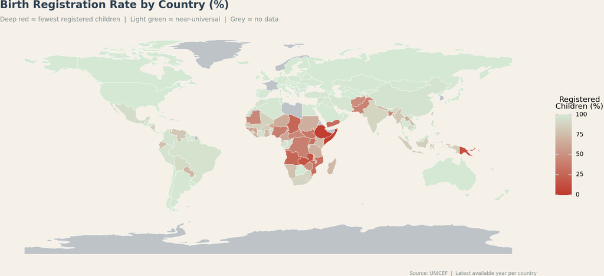

```python
map_br = world.merge(
    br_latest[["alpha_3_code", "obs_value"]],
    left_on="iso_a3", right_on="alpha_3_code", how="left"
)

(
    ggplot(map_br)
    + geom_map(aes(fill="obs_value"), color="#FFFFFF", size=0.2)
    + scale_fill_gradient(
        low=C_RED, high="#D5E8D4",
        name="Registered\nChildren (%)",
        na_value="#BDC3C7", limits=(0, 100)
    )
    + labs(
        title="Birth Registration Rate by Country (%)",
        subtitle="Deep red = fewest registered children  |  Light green = near-universal  |  Grey = no data",
        caption="Source: UNICEF  |  Latest available year per country"
    )
    + theme_void()
    + theme(
        figure_size=(12, 5.5),
        plot_title=element_text(size=15, weight="bold", color=C_DARK),
        plot_subtitle=element_text(size=9, color=C_GREY),
        plot_caption=element_text(size=7, color=C_GREY),
        panel_background=element_rect(fill=C_SAND),
        plot_background=element_rect(fill=C_SAND),
    )
)
```

> Countries with the lowest birth registration are overwhelmingly concentrated in **Sub-Saharan Africa and fragile states**. Weak administrative systems, poverty, and limited access to public services leave millions born without legal identity.

**🌊 Water Access Map**

**Where do children lack access to safely managed drinking water?**

**Safe water access world map code**

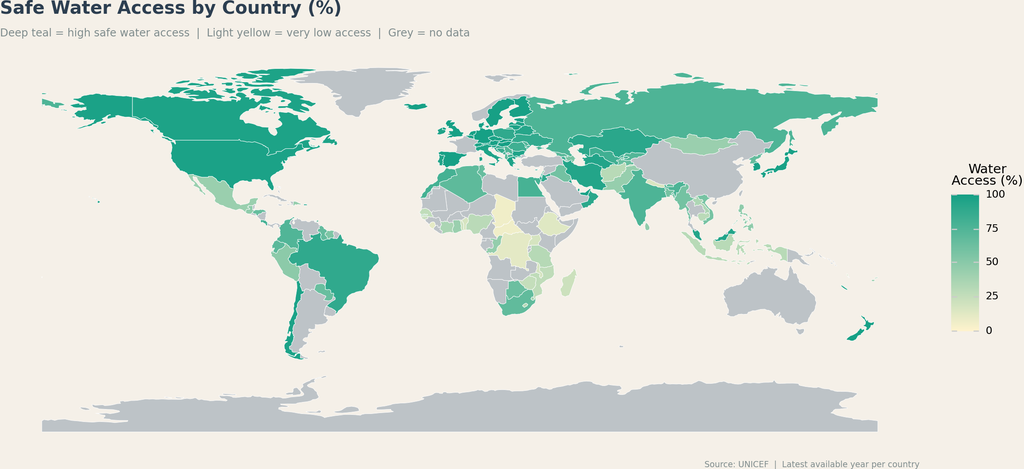

```python
map_sw = world.merge(
    sw_latest[["alpha_3_code", "obs_value"]],
    left_on="iso_a3", right_on="alpha_3_code", how="left"
)

(
    ggplot(map_sw)
    + geom_map(aes(fill="obs_value"), color="#FFFFFF", size=0.2)
    + scale_fill_gradient(
        low="#FFF3CD", high="#16A085",
        name="Water\nAccess (%)",
        na_value="#BDC3C7", limits=(0, 100)
    )
    + labs(
        title="Safe Water Access by Country (%)",
        subtitle="Deep teal = high safe water access  |  Light yellow = very low access  |  Grey = no data",
        caption="Source: UNICEF  |  Latest available year per country"
    )
    + theme_void()
    + theme(
        figure_size=(12, 5.5),
        plot_title=element_text(size=15, weight="bold", color=C_DARK),
        plot_subtitle=element_text(size=9, color=C_GREY),
        plot_caption=element_text(size=7, color=C_GREY),
        panel_background=element_rect(fill=C_SAND),
        plot_background=element_rect(fill=C_SAND),
    )
)
```

> Sub-Saharan Africa and parts of South Asia show the lowest access to safely managed drinking water. These are the same regions with the lowest birth registration rates, confirming that **both crises share the same root cause: failing public services.**

**📊 Bar Chart**

**Which 15 countries fail their children the most?**

Bars are colour-coded by severity: 🔴 *Critical* = under 10% registered | 🟠 *Severe* = 10–25% | 🟡 *High* = 25–50%

**Bar chart code**

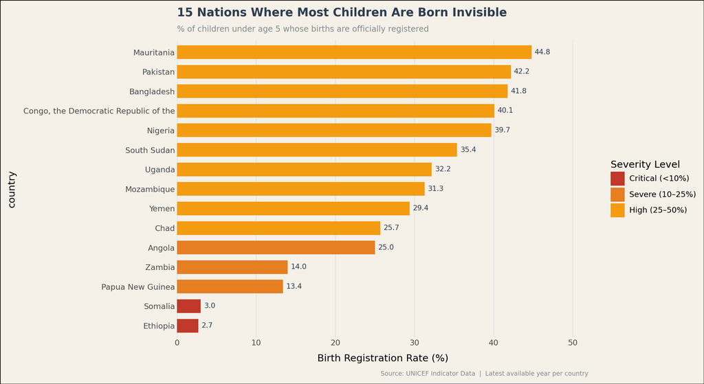

```python
bottom15 = (
    br_latest.nsmallest(15, "obs_value")
             .sort_values("obs_value")
             .assign(country=lambda d: pd.Categorical(
                 d["country"], categories=d["country"], ordered=True))
)
bottom15["band"] = pd.cut(
    bottom15["obs_value"], bins=[-1, 10, 25, 50],
    labels=["Critical (<10%)", "Severe (10–25%)", "High (25–50%)"]
)
band_colors = {
    "Critical (<10%)": C_RED,
    "Severe (10–25%)": C_ORG,
    "High (25–50%)":   C_GOLD,
}

(
    ggplot(bottom15, aes(x="country", y="obs_value", fill="band"))
    + geom_col(width=0.7)
    + geom_text(aes(label="obs_value.round(1)"),
                ha="left", nudge_y=0.4, size=8, color=BLACK)
    + scale_fill_manual(values=band_colors, name="Severity Level")
    + coord_flip()
    + scale_y_continuous(limits=(0, 52), expand=(0, 0))
    + labs(
        title="15 Nations Where Most Children Are Born Invisible",
        subtitle="% of children under age 5 whose births are officially registered",
        x=None, y="Birth Registration Rate (%)",
        caption="Source: UNICEF Indicator Data  |  Latest available year per country"
    )
    + theme_minimal()
    + theme(
        figure_size=(11, 6),
        plot_title=element_text(size=13, weight="bold", color=C_DARK),
        plot_subtitle=element_text(size=9, color=C_GREY),
        plot_caption=element_text(size=7, color=C_GREY),
        panel_background=element_rect(fill=C_SAND),
        plot_background=element_rect(fill=C_SAND),
        panel_grid_major_y=element_blank(),
        panel_grid_minor=element_blank(),
        legend_position="right",
    )
)
```

> **Ethiopia records just 2.7%** 97 in 100 children born with no legal proof of existence. Without a birth certificate, a child cannot enrol in school, access healthcare, or claim any legal protection.

**📈 Time Series**

**Is the water crisis improving and for whom?**

Tracking safe water access across six heavily affected countries from 2000 to 2024.

**Time series code**

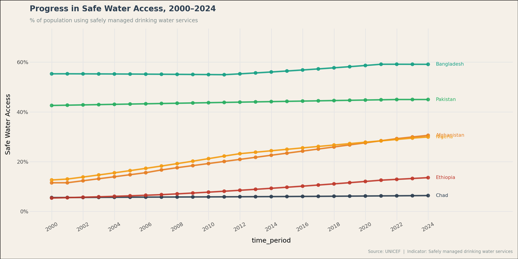

```python
country_colors = {
    "Bangladesh":  C_TEAL,
    "Pakistan":    C_GREEN,
    "Afghanistan": C_ORG,
    "Nigeria":     C_GOLD,
    "Ethiopia":    C_RED,
    "Chad":        C_DARK,
}

(
    ggplot(ts_df, aes(x="time_period", y="obs_value",
                      color="country", group="country"))
    + geom_line(size=1.4, alpha=0.9)
    + geom_point(size=2.5, alpha=0.85)
    + geom_text(
        data=ts_end,
        mapping=aes(x="time_period", y="obs_value",
                    label="country", color="country"),
        nudge_x=0.5, ha="left", size=8
    )
    + scale_color_manual(values=country_colors, guide=None)
    + scale_x_continuous(breaks=list(range(2000, 2025, 2)),
                         limits=(2000, 2028))
    + scale_y_continuous(limits=(0, 70),
                         labels=lambda l: [f"{int(v)}%" for v in l])
    + labs(
        title="Progress in Safe Water Access, 2000–2024",
        subtitle="% of population using safely managed drinking water services",
        x=None, y="Safe Water Access",
        caption="Source: UNICEF  |  Indicator: Safely managed drinking water services"
    )
    + theme_minimal()
    + theme(
        figure_size=(12, 6),
        plot_title=element_text(size=13, weight="bold", color=C_DARK),
        plot_subtitle=element_text(size=9, color=C_GREY),
        plot_caption=element_text(size=7, color=C_GREY),
        panel_background=element_rect(fill=C_SAND),
        plot_background=element_rect(fill=C_SAND),
        panel_grid_minor=element_blank(),
        axis_text_x=element_text(angle=30),
        legend_position="none",
    )
)
```

**🔵 Scatter Plot**

**Do these two crises go hand in hand?**

Each bubble is one country. Bigger bubbles = larger population. Colour shows birth registration rate red = low, green = high.

**Scatter plot code**

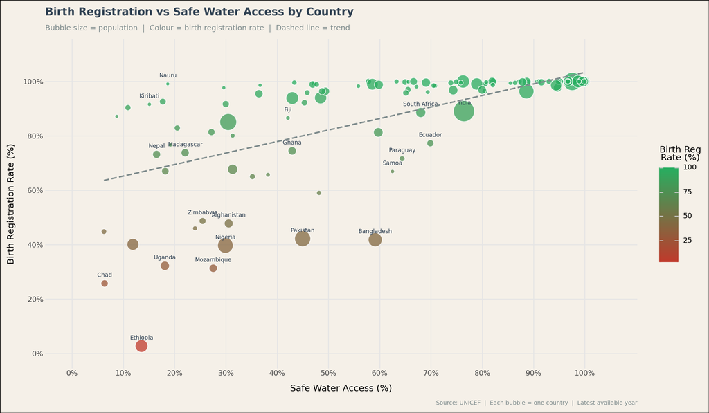

```python
label_countries = [
    "Ethiopia","Chad","Mozambique","Uganda","Nigeria","Afghanistan",
    "Bangladesh","Pakistan","Zimbabwe","Ghana","Nepal","Madagascar",
    "Kiribati","Nauru","Fiji","India","Paraguay","Samoa",
    "South Africa","Ecuador","Zambia","Somalia"
]
scatter_df["label"] = scatter_df["country"].apply(
    lambda c: c if c in label_countries else ""
)

(
    ggplot(scatter_df, aes(x="water_access", y="birth_reg"))
    + geom_point(aes(size="pop_sz", fill="birth_reg"),
                 color="white", alpha=0.75, shape="o")
    + geom_text(aes(label="label"), size=7,
                nudge_y=3, color=C_DARK, ha="center")
    + geom_smooth(method="lm", color=C_GREY,
                  se=False, linetype="dashed", size=1)
    + scale_fill_gradient(low=C_RED, high=C_GREEN,
                          name="Birth Reg\nRate (%)")
    + scale_size_continuous(range=(2, 14), guide=None)
    + scale_x_continuous(limits=(0, 105),
                         breaks=list(range(0, 101, 10)),
                         labels=lambda l: [f"{int(v)}%" for v in l])
    + scale_y_continuous(limits=(0, 110),
                         breaks=list(range(0, 101, 20)),
                         labels=lambda l: [f"{int(v)}%" for v in l])
    + labs(
        title="Birth Registration vs Safe Water Access by Country",
        subtitle="Bubble size = population  |  Colour = birth registration rate  |  Dashed line = trend",
        x="Safe Water Access (%)",
        y="Birth Registration Rate (%)",
        caption="Source: UNICEF  |  Each bubble = one country  |  Latest available year"
    )
    + theme_minimal()
    + theme(
        figure_size=(12, 7),
        plot_title=element_text(size=13, weight="bold", color=C_DARK),
        plot_subtitle=element_text(size=9, color=C_GREY),
        plot_caption=element_text(size=7, color=C_GREY),
        panel_background=element_rect(fill=C_SAND),
        plot_background=element_rect(fill=C_SAND),
        panel_grid_minor=element_blank(),
    )
)
```

> Countries in the **bottom-left** (low water, low registration) are almost entirely Sub-Saharan Africa. Countries in the **top-right** are Europe and East Asia. **Both crises are driven by the same root cause institutional failure.**

## What the Data Tells Us

### The Pattern Is Clear

The countries that fail to register births are the same countries that fail to provide safe water. This is not a coincidence it is the signature of **state failure**.

When a government cannot maintain civil registration systems, it almost certainly cannot maintain water infrastructure either. And when children lack both a legal identity *and* access to clean water, the consequences compound across a lifetime:

- ❌ No birth certificate → no school enrolment
- ❌ No clean water → poor health, missed school
- ❌ Both missing → a generation locked out of opportunity

### What Must Change

**Immediate actions needed:**

1. 📋 **Universal birth registration** free, automatic, and available at every health facility
2. 💧 **Investment in water infrastructure** particularly in Sub-Saharan Africa
3. 📱 **Digital civil registration** mobile-based systems to reach remote communities
4. 📊 **Consistent data collection** countries cannot fix what they cannot measure

**The bottom line:**

> *“Strengthening public services, improving governance, and investing in basic infrastructure are critical steps toward ensuring that every child is counted, protected, and given a legal identity.”*

## Data Sources

| File | Indicator | Countries |
| --- | --- | --- |
| `unicef_indicator_1.csv` | % using safely managed drinking water | 159 |
| `unicef_indicator_2.csv` | % of children under 5 with birth registered | 183 |
| `unicef_metadata.csv` | GDP, population, life expectancy | 211 |

*Visualisations produced with Python (plotnine, geopandas, pandas). Rendered with Quarto.*

**UNICEF For Every Child**  
Every child deserves an identity. Every child deserves clean water. The data demands action.